# Course Project 2

Benjamin Phillips [My code on github](https://github.com/BenjaminPhillips22/Reproducible_Research/tree/master/Course_Project_2)

## Introduction

Storms and other severe weather events can cause both public health and economic problems for communities and municipalities. Many severe events can result in fatalities, injuries, and property damage, and preventing such outcomes to the extent possible is a key concern.

This project involves exploring the U.S. National Oceanic and Atmospheric Administration’s (NOAA) storm database. This database tracks characteristics of major storms and weather events in the United States, including when and where they occur, as well as estimates of any fatalities, injuries, and property damage.

## Data

The data for this assignment come in the form of a comma-separated-value file compressed via the bzip2 algorithm to reduce its size. You can download the file from the course web site:

- [Storm Data](https://d396qusza40orc.cloudfront.net/repdata%2Fdata%2FStormData.csv.bz2)

There is also some documentation of the database available. Here you will find how some of the variables are constructed/defined.

- National Weather Service [Storm Data Documentation](https://d396qusza40orc.cloudfront.net/repdata%2Fpeer2_doc%2Fpd01016005curr.pdf)
- National Climatic Data Center Storm Events [FAQ](https://d396qusza40orc.cloudfront.net/repdata%2Fpeer2_doc%2FNCDC%20Storm%20Events-FAQ%20Page.pdf)

```r
# original file URL
downloadUrl <- "https://d396qusza40orc.cloudfront.net/repdata%2Fdata%2FStormData.csv.bz2"

# file check
if (!file.exists("storm_data.csv.bz2") ) {
    print("downloading data from website")
    download.file(downloadUrl, destfile = "storm_data.csv.bz2")
}

#read in data or not if it's already loaded
if(!"storm_data" %in% ls()){
    print("loading data")
    storm_data <- read.csv("storm_data.csv.bz2")
}
```

```
## [1] "loading data"
```

download packages

```r
library(tidyr)
library(ggplot2)
library(gridExtra)
library(dplyr)
names(storm_data)
```

```
##  [1] "STATE__"    "BGN_DATE"   "BGN_TIME"   "TIME_ZONE"  "COUNTY"
##  [6] "COUNTYNAME" "STATE"      "EVTYPE"     "BGN_RANGE"  "BGN_AZI"
## [11] "BGN_LOCATI" "END_DATE"   "END_TIME"   "COUNTY_END" "COUNTYENDN"
## [16] "END_RANGE"  "END_AZI"    "END_LOCATI" "LENGTH"     "WIDTH"
## [21] "F"          "MAG"        "FATALITIES" "INJURIES"   "PROPDMG"
## [26] "PROPDMGEXP" "CROPDMG"    "CROPDMGEXP" "WFO"        "STATEOFFIC"
## [31] "ZONENAMES"  "LATITUDE"   "LONGITUDE"  "LATITUDE_E" "LONGITUDE_"
## [36] "REMARKS"    "REFNUM"
```

We are interested in EVTYPE, FATALITIES, INJURIES, PROPDMG, PROPDMGEXP, CROPDMG, CROPDMGEXP

## Across the United States, which types of events (as indicated in the EVTYPE variable) are most harmful with respect to population health?

Get the sum of fatalities and injuries for each event type

```r
health_data <- storm_data %>%
    tbl_df() %>%
    select(EVTYPE, FATALITIES, INJURIES) %>%
    group_by(EVTYPE) %>%
    summarise(fatalities = sum(FATALITIES), injuries = sum(INJURIES))
```

Re-order and use the top 10

```r
fatalities_top10 <- health_data %>%
    select(EVTYPE, fatalities) %>%
    arrange(desc(fatalities)) %>%
    head(10)


injuries_top10 <- health_data %>%
    select(EVTYPE, injuries) %>%
    arrange(desc(injuries)) %>%
    head(10)
```

Create the graphs

```r
g1 <- ggplot(data = fatalities_top10, aes(x = reorder(EVTYPE, -fatalities), fatalities)) +
    geom_bar(stat = "identity") +
    ggtitle("Total Fatalities per Event Type") +
    xlab("Event") +
    ylab("total fatalities") +
    theme(axis.text.x = element_text(angle = 45, hjust = 1, size = 12))


g2 <- ggplot(data = injuries_top10, aes(x = reorder(EVTYPE, -injuries), injuries)) +
    geom_bar(stat = "identity") +
    ggtitle("Total injuries per Event Type") +
    xlab("Event") +
    ylab("total injuries") +
    theme(axis.text.x = element_text(angle = 45, hjust = 1, size = 12))
```

Let’s compare both fatalities and injuries. Make the plots the same size and print

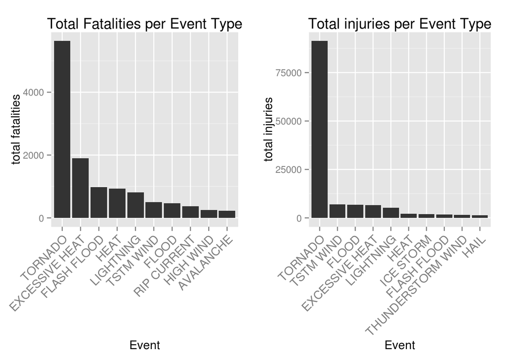

```r
gA <- ggplotGrob(g1)
gB <- ggplotGrob(g2)
maxHeight = grid::unit.pmax(gA$heights[2:5], gB$heights[2:5])
gA$heights[2:5] <- as.list(maxHeight)
gB$heightss[2:5] <- as.list(maxHeight)

grid.arrange(gA, gB, nrow=1)
```

Tornados seem to be responsible for the most injuries and fatalities.

## Across the United States, which types of events have the greatest economic consequences?

Select the columns we need

```r
economic_data <- storm_data %>%
    tbl_df() %>%
    select(EVTYPE, PROPDMG, PROPDMGEXP, CROPDMG, CROPDMGEXP)
```

```r
unique(economic_data$PROPDMGEXP)
```

```
##  [1] K M   B m + 0 5 6 ? 4 2 3 h 7 H - 1 8
## Levels:  - ? + 0 1 2 3 4 5 6 7 8 B h H K m M
```

```r
unique(economic_data$CROPDMGEXP)
```

```
## [1]   M K m B ? 0 k 2
## Levels:  ? 0 2 B k K m M
```

Clean up the data, make PROPDMG and CROPDMG into usable numbers

```r
exps <- c(K=1e3, k=1e3, M=1e6, B=1e9, m=1e6, h=1e2, H=1e2, "?"=1, "-"=1, "+"=1,
          "0"=1, "1"=1, "2"=1e2, "3"=1e3, "4"=1e4, "5"=1e5, "6"=1e6, "7"=1e7, "8"=1e8)

economic_data$PROPDMGEXP <- as.character(economic_data$PROPDMGEXP)
economic_data$PROPDMGEXP[economic_data$PROPDMGEXP==""] <- 1
economic_data$PROPDMGEXP  <- exps[economic_data$PROPDMGEXP]

economic_data$CROPDMGEXP <- as.character(economic_data$CROPDMGEXP)
economic_data$CROPDMGEXP[economic_data$CROPDMGEXP==""] <- 1
economic_data$CROPDMGEXP  <- exps[economic_data$CROPDMGEXP]
```

Make PROPDMG and CROPDMG a factor, not a variable

```r
costs_data <- economic_data %>%
    mutate(PROPDMG=PROPDMG*PROPDMGEXP, CROPDMG=CROPDMG*CROPDMGEXP) %>%
    select(EVTYPE,PROPDMG,CROPDMG) %>%
    gather(key = damage.type, value = cost, c(PROPDMG,CROPDMG)) %>%
    group_by(EVTYPE)
```

Get top 10 costly events

```r
costs_top10_events <- costs_data  %>%
    summarise(total.cost = sum(cost)) %>%
    arrange(desc(total.cost)) %>%
    select(EVTYPE) %>%
    head(10)
```

Filter costs_data for events just in the top 10 and aggregate cost on event type and damage type

```r
costs_data <- costs_data %>%
    filter(EVTYPE %in% unlist(costs_top10_events))  %>%
    group_by(EVTYPE, damage.type) %>%
    summarise(cost = sum(cost))
```

plot it

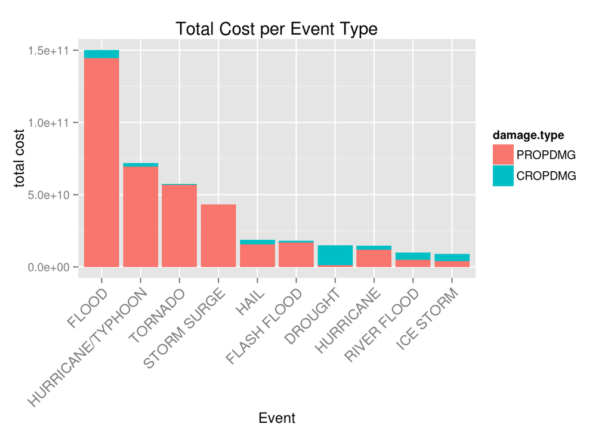

```r
g3 <- ggplot(data = costs_data, aes(x=reorder(EVTYPE,-cost), y=cost, fill=damage.type)) +
    geom_bar(stat="identity") +
    ggtitle("Total Cost per Event Type") +
    xlab("Event") +
    ylab("total cost") +
    theme(axis.text.x = element_text(angle = 45, hjust = 1, size = 12))
print(g3)
```

Benjamin Phillips